# 쇼생크 탈출 — 시간의 형식을 읽다

Culture Voyager #1 | 볼수록 좋아지는 영화의 비밀

Author

Nakcho Choi

Published

May 2, 2026

## 고백부터 하자

나는 이 영화를 30대에 처음 봤다. 솔직히 말하면 “아, 좋은 영화네” 정도였다. 줄거리 좋고, 반전 있고, 모건 프리먼 목소리 좋고.

박구용 교수가 이명세 감독에 대해 말했다: “귀중한 걸 어렸을 때 경험하지 못했구나.” 나도 이 영화를 20대에 제대로 못 봤다. 그때는 다른 것에 취해 있었으니까. 하지만 괜찮다. **이 영화는 기다려주는 영화니까.**

## 블랙홀 장면: 피가로의 결혼이 울리는 30초

위대한 영화에는 모든 것을 빨아들이는 한 장면이 있다. 이명세 감독은 그런 장면 하나에서 영화를 시작한다고 했다. “블랙홀처럼 많은 내용을 숨기고 있는 한 장의 장면.”

쇼생크의 블랙홀은 여기다: **앤디가 방송실 문을 잠그고 모차르트를 트는 30초.**

왜 이 30초에 영화 전체가 들어있나?

**첫째, 이것은 계산된 위반이다.** 앤디는 독방 2주라는 대가를 알고 있었다. 충동이 아니라 의지다. 이 남자의 본질 — 자유란 허락받는 게 아니라 행사하는 것.

**둘째, 곡 선택이 복선이다.** “Sull’aria” — 이 곡은 하녀 둘이 권력자를 속이기 위해 편지를 쓰는 장면의 노래다. 앤디가 워든(권력)에게 19년간 하고 있던 일의 예고편이다. (이걸 아는 사람이 거의 없다. 나도 세 번째 보고 알았다.)

**셋째, 레드의 나레이션.** “나는 그 음악이 무슨 뜻인지 몰랐다. 알 필요도 없었다.”

이 대사. 평생 감옥에서 기능적 언어만 쓰던 남자가, 태어나서 처음으로 **의미 없이도 아름다운 것이 존재한다**는 사실을 경험한 순간이다. 레드의 영혼에 금이 간 순간. 그리고 그 금이 — 19년 뒤 지우아타네호 해변에서 열린다.

## 우리는 앤디를 모른다 — 그리고 그게 설계다

다라본트가 한 가장 대담한 결정. 주인공이 앤디인데, 서술자는 레드다.

처음엔 이상하다. 왜 앤디가 직접 이야기하지 않지? 그런데 이게 핵심이다: **앤디의 내면을 우리는 절대 직접 볼 수 없게 설계되어 있다.** 19년간 벽을 팠다는 것을 마지막에야 안다. 그가 실제로 뭘 느꼈는지 — 절망했는지, 포기하고 싶었는지 — 영원히 모른다.

앤디는 해독 불가능한 존재다. 그는 ’인물’이 아니라 ’사건’이다.

그래서 이 영화의 진짜 주인공은 **레드**다. 앤디를 바라보며 천천히 변하는 목격자. 관객이 동일시하는 대상도 레드다. 우리도 레드처럼 앤디를 바깥에서 보며, 천천히, 무언가가 바뀐다.

## 브룩스라는 거울 — 이 영화의 가장 잔인한 설계

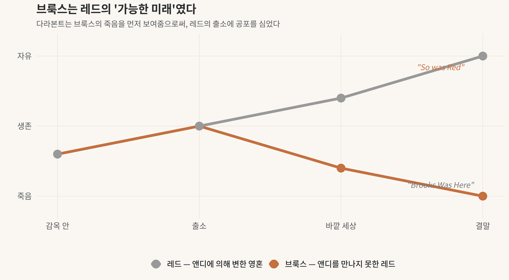

브룩스와 레드 — 다라본트가 설계한 거울

브룩스 해틀리. 50년 복역 후 가석방. 그리고 목을 맨다.

50대에 이 장면을 다시 보면, 단순한 슬픔이 아니라 **공포**가 온다. “나도 어딘가에 50년간 적응해서, 거기서 나오면 살 수 없는 상태가 되어 있는 건 아닌가?”

직장 30년. 한 동네 20년. 한 관계 25년. 우리는 모두 무언가에 ’제도화’되어 있다. 브룩스의 비극은 먼 이야기가 아니다.

그리고 다라본트의 잔인한 설계: 브룩스의 죽음은 **레드의 출소 전에 배치된다.** 관객은 이미 “나가면 죽을 수 있다”는 것을 봤다. 그래서 레드가 출소할 때 — 관객도 레드와 함께 두렵다. “이 사람도 죽으면 어쩌지.”

그 공포를 깨뜨리는 것: 앤디가 남긴 편지. “희망은 좋은 것이야. 좋은 것은 죽지 않아.”

## 세 번의 가석방 — 자유는 언어에서 시작된다

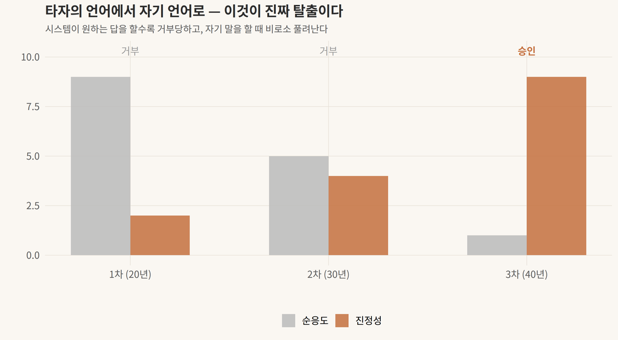

역설: 시스템에 순응할수록 거부당한다

레드의 세 번째 가석방 심사. “솔직히 ’갱생’이라는 단어가 무슨 뜻인지 모르겠습니다.”

이것이 푸코가 말한 것이다 — 정상과 비정상을 결정하는 것 자체가 권력이다. 가석방 위원회는 “갱생했습니까?”라는 질문으로 정상/비정상을 결정하는 권력을 행사한다. 레드가 “그 단어가 뭔 뜻인지 모르겠다”고 말하는 순간, 그는 **그 프레임 자체를 거부한** 것이다.

그리고 역설적으로, 그때 풀려난다.

웃긴 일이다. 40년 동안 “네, 갱생했습니다”라고 바르게 말했을 때는 계속 거부당하고, “솔직히 모르겠습니다”라고 한 순간 승인된다. 시스템은 순종을 원하는 척하지만, 실제로는 진정성을 읽을 줄 안다. (아니, 다라본트가 관객에게 그렇게 믿게 만든 것이다.)

## 이 영화가 나이 들수록 좋아지는 이유

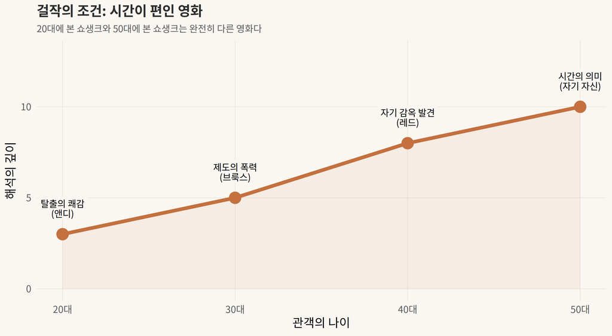

같은 영화, 다른 영화 — 경험이 쌓일수록 깊은 층위가 열린다

20대: “야, 멋있다. 탈출 쩐다.” 30대: “브룩스가 불쌍하네. 사회가 저럴 수 있구나.” 40대: “잠깐, 나도 어딘가에 갇혀 있는 거 아니야?” 50대: “지질학은 시간과 압력의 문제야” — 이 말이 비로소 내 몸으로 들어온다.

프랭크 다라본트는 이후 이 높이를 다시는 넘지 못했다. 그린 마일(1999)은 좋은 영화지만, 쇼생크의 설계적 완성도에는 못 미친다. 다라본트 자신도 예술의 법정에 봉인된 셈이다 — 자기 최고작의 그림자 속에.

하지만 그것이 예술가의 운명이다. 한 번이라도 그 높이에 도달했다면 — 그것으로 된 것이다.

> “바쁘게 살거나, 바쁘게 죽거나.”

이것은 한 번의 선택이 아니다. 매일 아침, 눈을 뜰 때마다 하는 선택이다.

*다음 호: 인터스텔라 — 놀란은 왜 5차원을 ’책장’으로 설계했는가*

*Culture Voyager Vol.01 | 2026.05.02*